# Returns

David Chow

Monday, July 27, 2015

Read the data set **Stock_FX_bond.csv** contains the volumes and *adjusted closing* (AC) prices of stocks and the *S&P 500* (columns B–W), *yields on bonds* (columns X–AD).

### Compare GM and Ford returns

Do the GM and Ford returns seem positively correlated? Do you notice any outlying returns? If “yes,” do outlying GM returns seem to occur with outlying Ford returns?

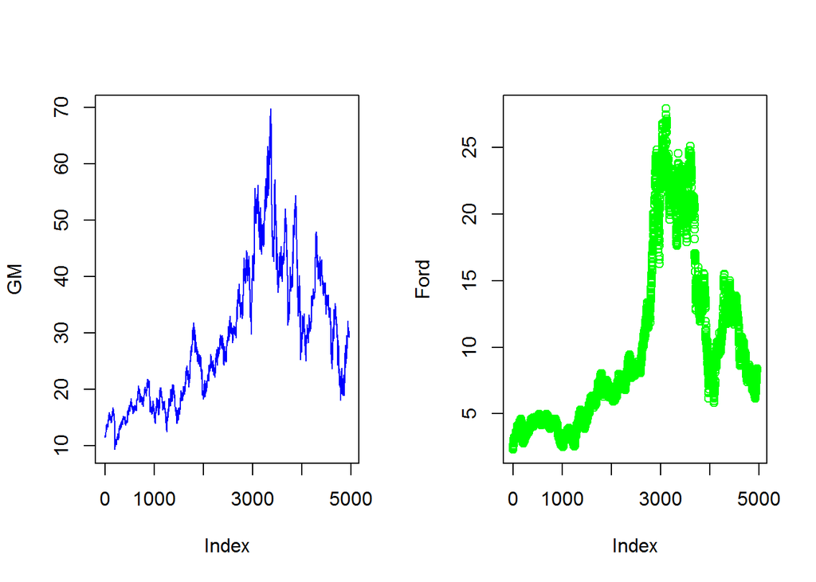

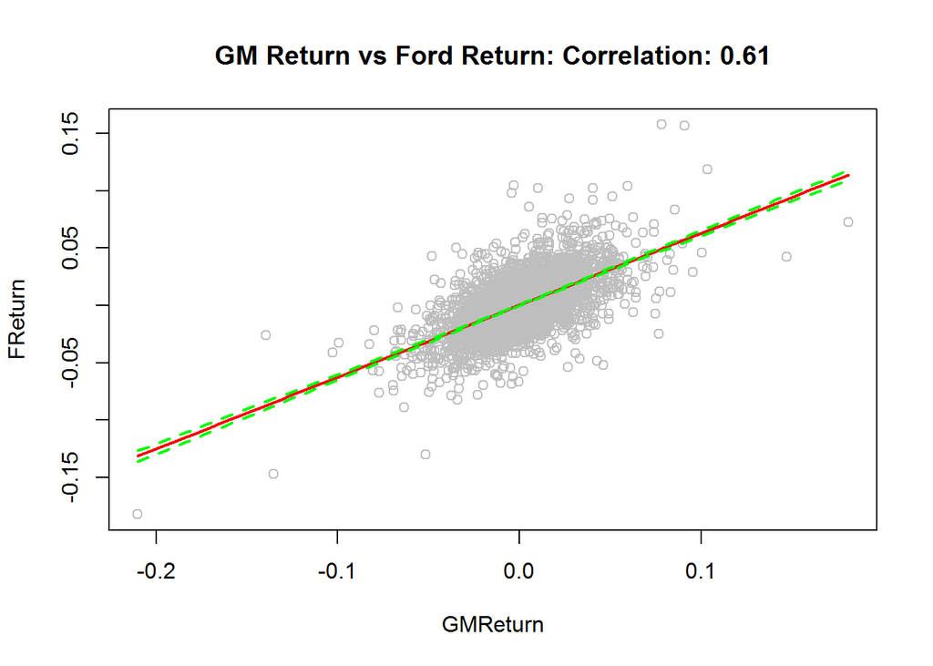

### Simulations

Suppose a hedge fund owns $1,000,000 of stock and used $50,000 of its own capital and $950,000 in borrowed money for the purchase. If the value of the stock falls below $950,000 at the end of any trading day, then the hedge fund must sell all the stock and repay the loan. This will wipe out its $50,000 investment. The hedge fund is said to be leveraged 20:1 since its position is 20 times the amount of its own capital invested.

The daily log returns on the stock have a mean of 0.05/year and a standard deviation of 0.23/year. These can be converted to rates per trading day by dividing by 253 and v253, respectively.

**What is the probability that the value of the stock will be below $950,000 at the close of at least one of the next 45 trading days?**

```
## [1] 0.508546
```

Suppose the hedge fund will sell the stock for a profit of at least $100,000 if the value of the stock rises to at least $1,100,000 at the end of one of the first 100 trading days, sell it for a loss if the value falls below $950,000 at the end of one of the first 100 trading days, or sell after 100 trading days if the closing price has stayed between $950,000 and $1,100,000.

**What is the probability that the hedge fund will make a profit of at least $100,000?**

```
## [1] 0.387998
```

**What is the probability the hedge fund will suffer a loss?**

```
## [1] 0.594163
```

**What is the expected profit from this trading strategy?**

```
## [1] 9033.849
```

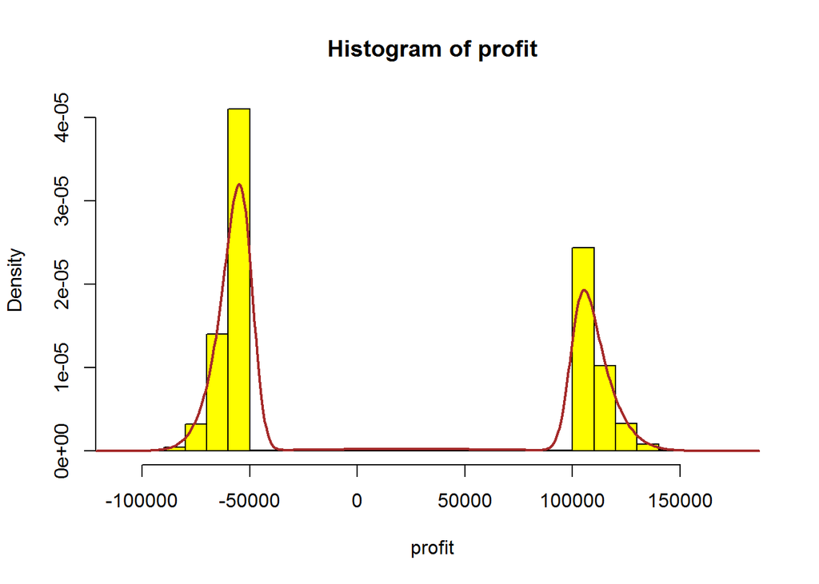

**What is the expected return?**  
When answering this question, remember that only $50,000 was invested. Also, the units of return are time, e.g., one can express a return as a daily return or a weekly return. Therefore, one must keep track of how long the hedge fund holds its position before selling.

```
## [1] "-2.2% daily"
```

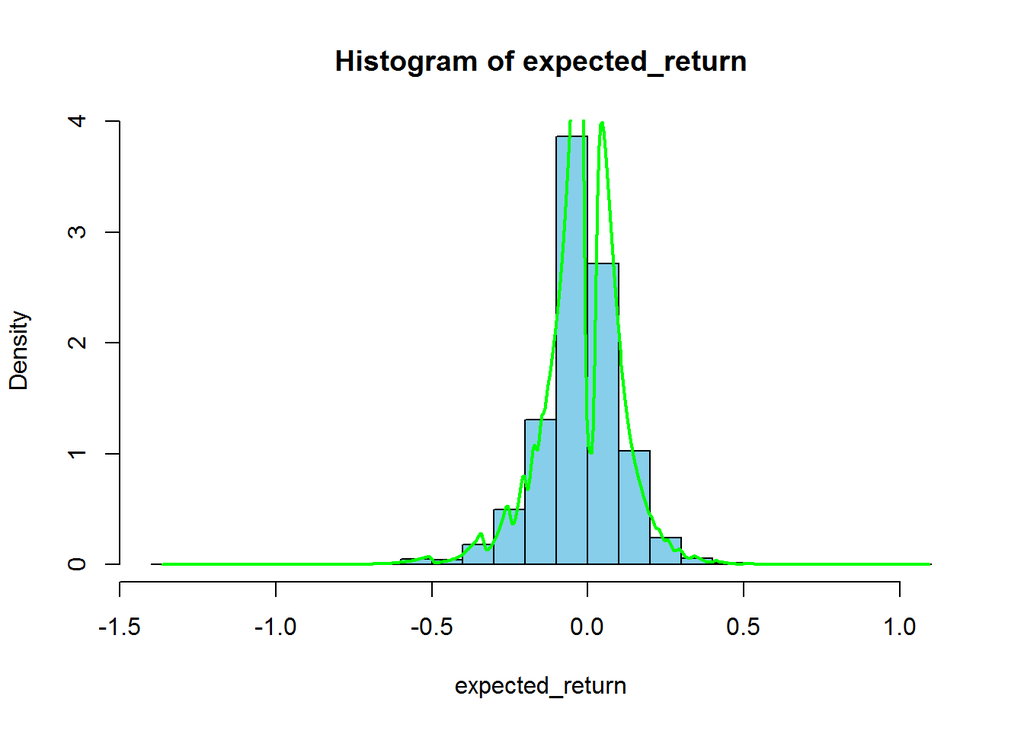